# Proses MA(2)

# Membangkitkan model MA(2) dengan 𝜃1 = 0.4 dan 𝜃2 = 0.6 sebanyak 300 data (Manual dan dengan arima.sim)

## Manual

```r
# Seed agar hasil dapat direplikasi
set.seed(123)

# Parameter
n <- 300
theta1 <- 0.4
theta2 <- 0.6

# Bangkitkan error/residual Z_t
z <- rnorm(n)

# Bangkitkan data MA(2)
x_manual <- numeric(n)

# Nilai awal
x_manual[1] <- z[1]
x_manual[2] <- z[2] + theta1 * z[1]

# Mulai dari t = 3
for (t in 3:n) {
  x_manual[t] <- z[t] +
    theta1 * z[t-1] +
    theta2 * z[t-2]
}

# Lihat 10 data pertama
head(x_manual, 10)
```

```
##  [1] -0.56047565 -0.45436775  1.13035193  0.55588522  1.09271608  1.80908512
##  [7]  1.22451484 -0.05165576 -0.91632762 -1.47943985
```

## `(arima.sim)`

```r
set.seed(123)

# Bangkitkan MA(2)
x_arima <- arima.sim(
  model = list(ma = c(0.4, 0.6)),
  n = 300
)

# Lihat 10 data pertama
head(x_arima, 10)
```

```
## Time Series:
## Start = 1
## End = 10
## Frequency = 1
##  [1]  1.13035193  0.55588522  1.09271608  1.80908512  1.22451484 -0.05165576
##  [7] -0.91632762 -1.47943985  0.63370530  0.58204936
```

# Membuat Plot time series, plot ACF, plot PACF dan plot EACF. Idenifikasi apakah data tersebut stasioner

## Plot time series

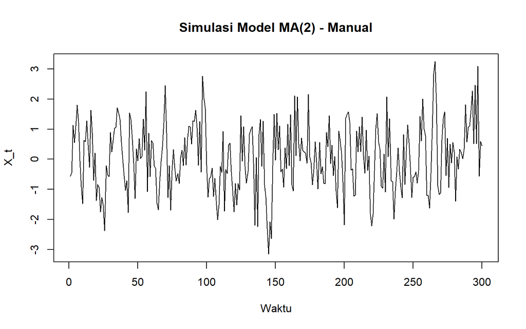

```r
# Plot MA(2) manual
plot(
  ts(x_manual),
  main = "Simulasi Model MA(2) - Manual",
  ylab = "X_t",
  xlab = "Waktu"
)
```

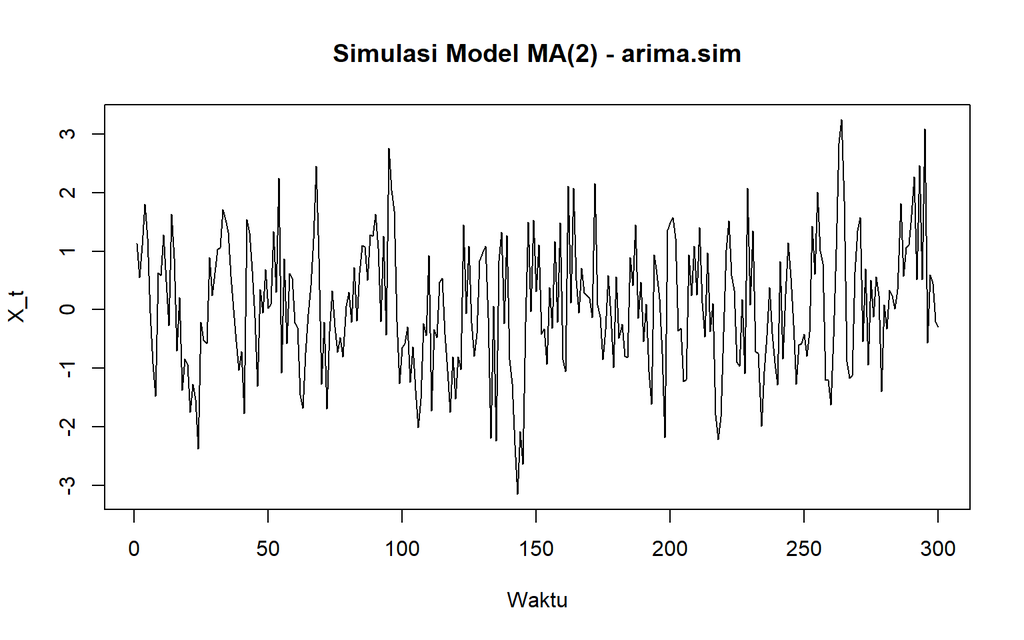

```r
# Plot MA(2) arima.sim
plot(
  ts(x_arima),
  main = "Simulasi Model MA(2) - arima.sim",
  ylab = "X_t",
  xlab = "Waktu"
)
```

Berdasarkan Plot Simulasi Model MA(2) - Manual dan Simulasi Model MA(2) - arima.sim, plot tersebut menunjukkan:

1. Data berfluktuasi di sekitar rata-rata yang relatif konstan (sekitar 0)
2. Tidak terlihat adanya tren naik atau turun
3. Varians/penyebaran data relatif konstan sepanjang waktu
4. Tidak terlihat pola musiman yang jelas.

## Plot ACF

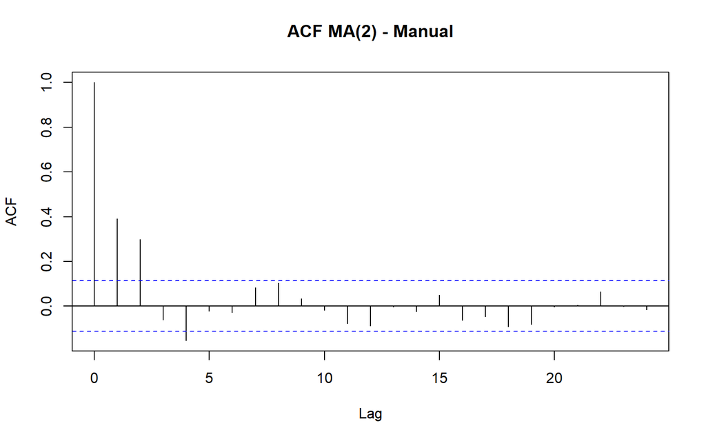

```r
acf(
  x_manual,
  main = "ACF MA(2) - Manual"
)
```

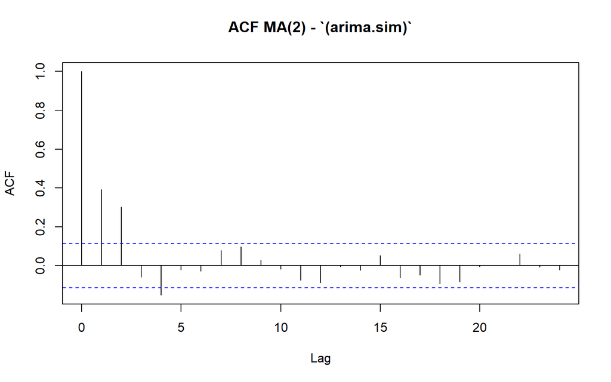

```r
acf(
  x_arima,
  main = "ACF MA(2) - `(arima.sim)`"
)
```

Berdasarkan Plot ACF MA(2) - Manual dan ACF MA(2) - `(arima.sim)` menunjukkan bahwa memiliki pola yang stasioner karena plot tersebut menunjukkan:

1. Lag 1 memiliki ACF sekitar 0,39 dan signifikan.
2. Lag 2 sekitar 0,30 dan signifikan.
3. Setelah lag 2, sebagian besar spike berada di sekitar nol dan tidak menunjukkan pola peluruhan yang panjang.

# Plot PACF

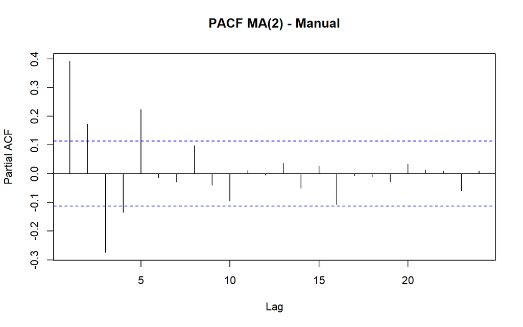

```r
pacf(
  x_manual,
  main = "PACF MA(2) - Manual"
)
```

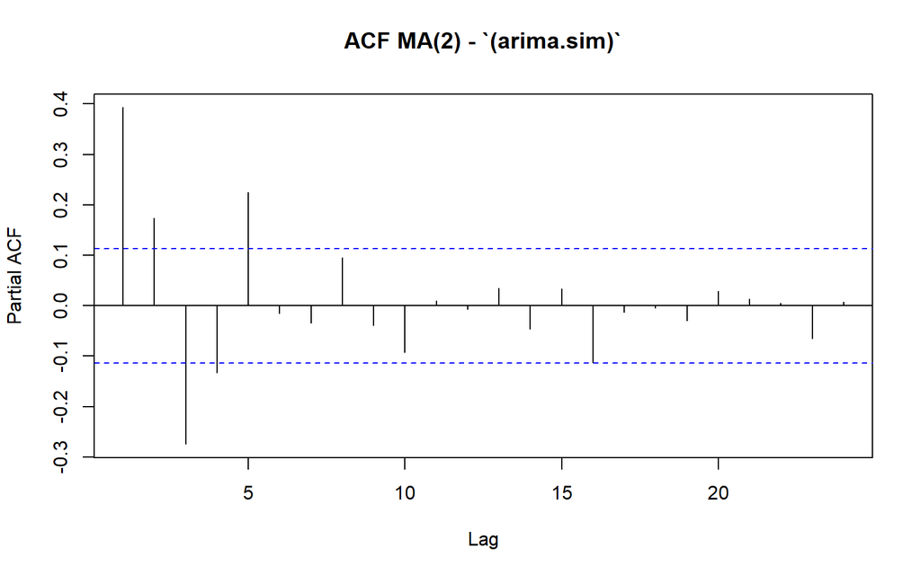

```r
pacf(
  x_arima,
  main = "ACF MA(2) - `(arima.sim)`"
)
```

Plot PACF MA(2) - Manual dan ACF MA(2) - `(arima.sim)` menunjukkan pola meluruh (tailing off), bukan terputus secara jelas pada lag tertentu.

# Plot EACF

```r
# Load package
library(TSA)
```

```r
# Plot EACF
eacf(x_manual)
```

```
## AR/MA
##   0 1 2 3 4 5 6 7 8 9 10 11 12 13
## 0 x x o x o o o o o o o  o  o  o
## 1 x x x x o o o o o o o  o  o  o
## 2 x x o x o o o o o o o  o  o  o
## 3 x x o o x o o o o o o  o  o  o
## 4 x x x o x o o o o o o  o  o  o
## 5 o x x x x o o o o o o  o  o  o
## 6 x o x x x o o o o o o  o  o  o
## 7 x x o x x o o o o o o  o  o  o
```

```r
eacf(x_arima)
```

```
## AR/MA
##   0 1 2 3 4 5 6 7 8 9 10 11 12 13
## 0 x x o x o o o o o o o  o  o  o
## 1 x x x x o o o o o o o  o  o  o
## 2 x x o x o o o o o o o  o  o  o
## 3 x x o o x o o o o o o  o  o  o
## 4 x x x x x o o o o o o  o  o  o
## 5 o x x x x o o o o o o  o  o  o
## 6 x o x x o o o o o o o  o  o  o
## 7 x x o x x o o o o o o  o  o  o
```

# Membuat scatterplot antara Yt dengan Yt-1, Yt dengan Yt-2, serta Yt dengan Yt-3

## Scatterplot antara Yt dengan Yt-1

### Manual

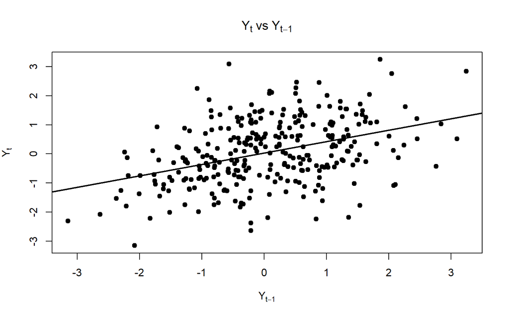

```r
plot(
  x_manual[-1],
  x_manual[-length(x_manual)],
  main = expression(Y[t] ~ "vs" ~ Y[t-1]),
  xlab = expression(Y[t-1]),
  ylab = expression(Y[t]),
  pch = 19
)

# Garis regresi
abline(
  lm(x_manual[-length(x_manual)] ~ x_manual[-1]),
  lwd = 2
)
```

### `(arima.sim)`

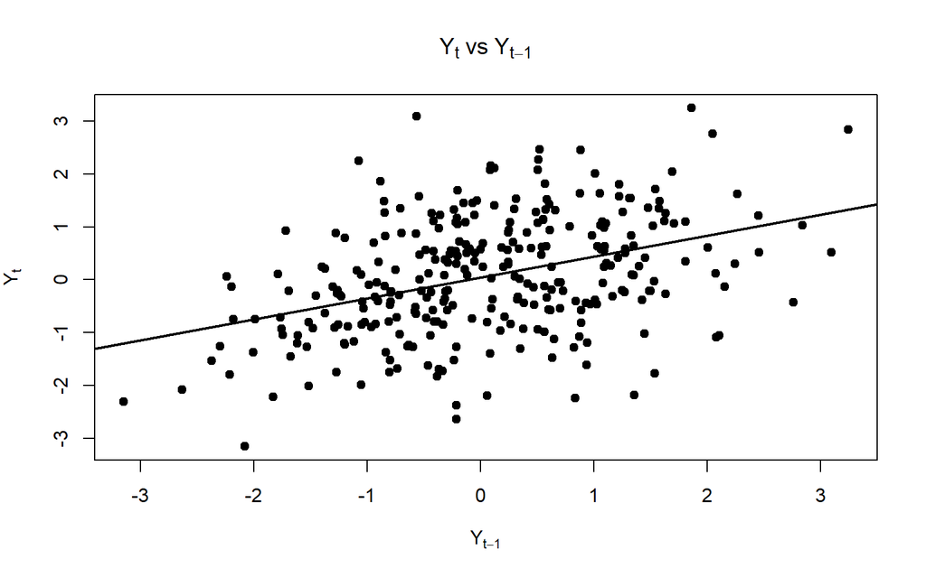

```r
plot(
  x_arima[-1],
  x_arima[-length(x_arima)],
  main = expression(Y[t] ~ "vs" ~ Y[t-1]),
  xlab = expression(Y[t-1]),
  ylab = expression(Y[t]),
  pch = 19
)

# Garis regresi
abline(
  lm(x_arima[-length(x_arima)] ~ x_arima[-1]),
  lwd = 2
)
```

## Scatterplot antara Yt dengan Yt-2

### Manual

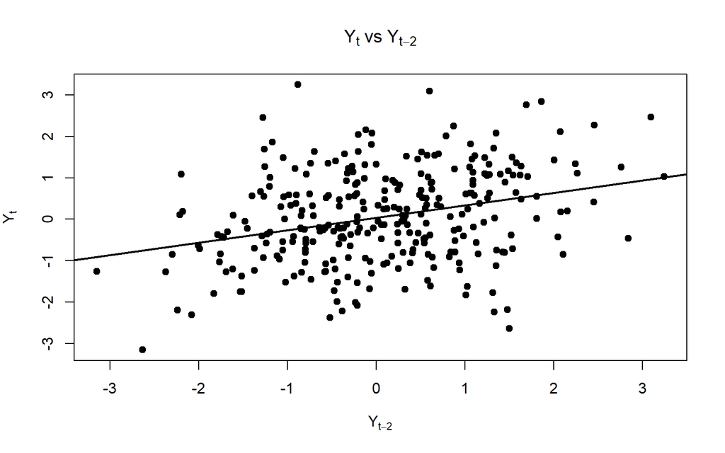

```r
plot(
  x_manual[-c(1,2)],
  x_manual[-c(length(x_manual)-1, length(x_manual))],
  main = expression(Y[t] ~ "vs" ~ Y[t-2]),
  xlab = expression(Y[t-2]),
  ylab = expression(Y[t]),
  pch = 19
)

# Garis regresi
abline(
  lm(
    x_manual[-c(length(x_manual)-1, length(x_manual))] ~
      x_manual[-c(1,2)]
  ),
  lwd = 2
)
```

### `(arima.sim)`

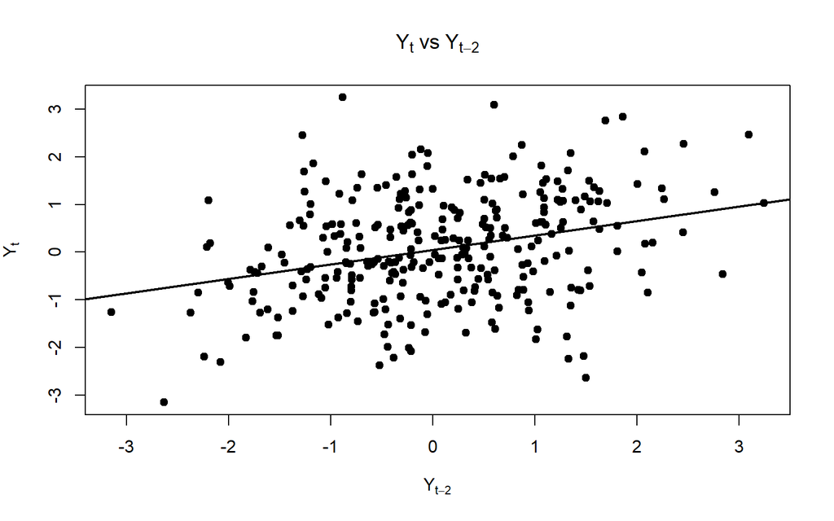

```r
plot(
  x_arima[-c(1,2)],
  x_arima[-c(length(x_arima)-1, length(x_arima))],
  main = expression(Y[t] ~ "vs" ~ Y[t-2]),
  xlab = expression(Y[t-2]),
  ylab = expression(Y[t]),
  pch = 19
)

# Garis regresi
abline(
  lm(
    x_arima[-c(length(x_arima)-1, length(x_arima))] ~
      x_arima[-c(1,2)]
  ),
  lwd = 2
)
```

## Scatterplot antara Yt dengan Yt-3

### Manual

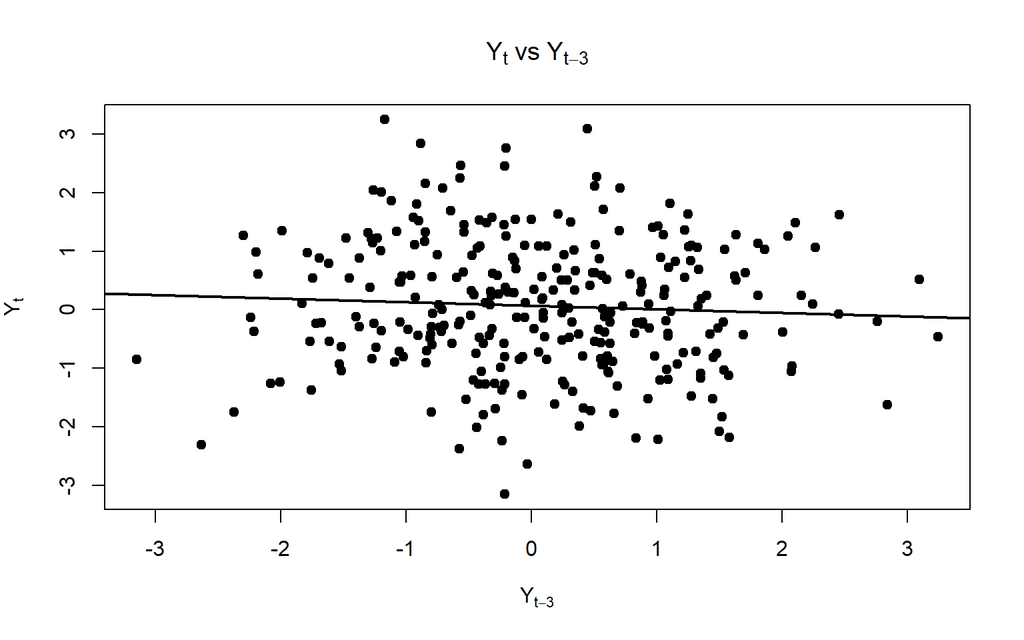

```r
# Scatterplot Yt vs Yt-3
plot(
  x_manual[4:length(x_manual)],
  x_manual[1:(length(x_manual)-3)],
  main = expression(Y[t] ~ "vs" ~ Y[t-3]),
  xlab = expression(Y[t-3]),
  ylab = expression(Y[t]),
  pch = 19
)

# Garis regresi
abline(
  lm(
    x_manual[4:length(x_manual)] ~
      x_manual[1:(length(x_manual)-3)]
  ),
  lwd = 2
)
```

### `(arima.sim)`

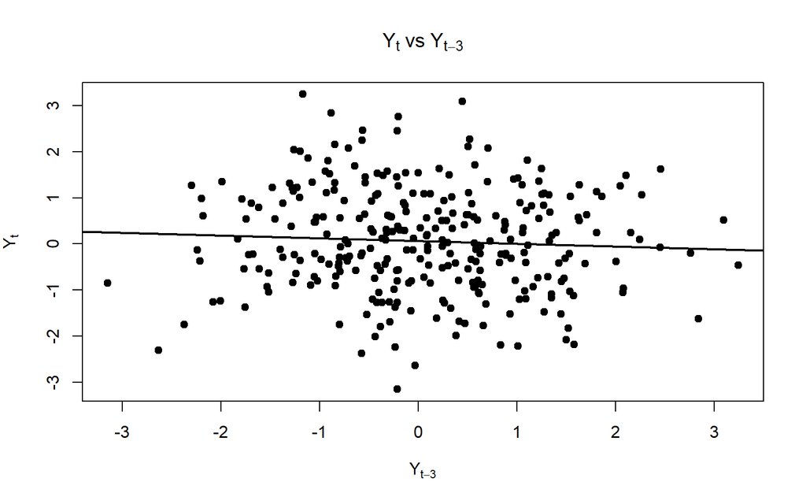

```r
# Scatterplot Yt vs Yt-3
plot(
  x_arima[4:length(x_arima)],
  x_arima[1:(length(x_arima)-3)],
  main = expression(Y[t] ~ "vs" ~ Y[t-3]),
  xlab = expression(Y[t-3]),
  ylab = expression(Y[t]),
  pch = 19
)

# Garis regresi
abline(
  lm(
    x_arima[4:length(x_arima)] ~
      x_arima[1:(length(x_arima)-3)]
  ),
  lwd = 2
)
```

# Mengitung autokorelasi masing masing baik dari data bangkitan maupun secara teoritis

## Autokorelasi dari data bangkitan

### Manual

```r
# Autokorelasi data bangkitan
acf_sample <- acf(
  x_manual,
  lag.max = 10,
  plot = FALSE
)

# Tampilkan nilai ACF
acf_sample$acf
```

```
## , , 1
##
##              [,1]
##  [1,]  0.39182775
##  [2,]  0.29938692
##  [3,] -0.06085596
##  [4,] -0.15370935
##  [5,] -0.02240737
##  [6,] -0.02796065
##  [7,]  0.08269750
##  [8,]  0.10284941
##  [9,]  0.03330451
## [10,] -0.01690221
```

### `(arima.sim)`

```r
# Autokorelasi data bangkitan
acf_sample1 <- acf(
  x_arima,
  lag.max = 10,
  plot = FALSE
)

# Tampilkan nilai ACF
acf_sample1$acf
```

```
## , , 1
##
##              [,1]
##  [1,]  0.39291332
##  [2,]  0.30149334
##  [3,] -0.05871740
##  [4,] -0.15129683
##  [5,] -0.02106944
##  [6,] -0.02832847
##  [7,]  0.07866522
##  [8,]  0.09719233
##  [9,]  0.02836503
## [10,] -0.01741908
```

## Autokorelasi teoritis MA(2)

```r
# Parameter MA(2)
theta1 <- 0.4
theta2 <- 0.6

# Penyebut
denominator <- 1 + theta1^2 + theta2^2

# ACF teoritis
rho1 <- theta1 * (1 + theta2) / denominator
rho2 <- theta2 / denominator

acf_theoretical <- c(
  1,
  rho1,
  rho2,
  rep(0, 8)
)

acf_theoretical
```

```
##  [1] 1.0000000 0.4210526 0.3947368 0.0000000 0.0000000 0.0000000 0.0000000
##  [8] 0.0000000 0.0000000 0.0000000 0.0000000
```

## Gabungan data bangkitan dan teoritis

Model:

$$Y_t=Z_t+0.4Z_{t-1}+0.6Z_{t-2}$$

Untuk MA(2), rumusnya:

$$\rho(1)= \frac{\theta_1(1+\theta_2)}
{1+\theta_1^2+\theta_2^2}$$

dan

$$\rho(2)= \frac{\theta_2}
{1+\theta_1^2+\theta_2^2}$$

Sedangkan:

$$\rho(k)=0,\quad k>2$$

### Manual

```r
# ACF data bangkitan
acf_sample <- acf(
  x_manual,
  lag.max = 10,
  plot = FALSE
)

# Parameter MA(2)
theta1 <- 0.4
theta2 <- 0.6

# Penyebut
denominator <- 1 + theta1^2 + theta2^2

# ACF teoritis
rho1 <- theta1 * (1 + theta2) / denominator
rho2 <- theta2 / denominator

acf_theoretical <- c(
  rho1,
  rho2,
  rep(0, 8)
)

# Tabel perbandingan
acf_comparison <- data.frame(
  Lag = 1:10,
  ACF_Bangkitan = as.numeric(acf_sample$acf),
  ACF_Teoritis = acf_theoretical
)

acf_comparison
```

```
##    Lag ACF_Bangkitan ACF_Teoritis
## 1    1    0.39182775    0.4210526
## 2    2    0.29938692    0.3947368
## 3    3   -0.06085596    0.0000000
## 4    4   -0.15370935    0.0000000
## 5    5   -0.02240737    0.0000000
## 6    6   -0.02796065    0.0000000
## 7    7    0.08269750    0.0000000
## 8    8    0.10284941    0.0000000
## 9    9    0.03330451    0.0000000
## 10  10   -0.01690221    0.0000000
```

### `(arima,sim)`

```r
# ACF data bangkitan
acf_sample1 <- acf(
  x_arima,
  lag.max = 10,
  plot = FALSE
)

# Parameter MA(2)
theta1 <- 0.4
theta2 <- 0.6

# Penyebut
denominator <- 1 + theta1^2 + theta2^2

# ACF teoritis
rho1 <- theta1 * (1 + theta2) / denominator
rho2 <- theta2 / denominator

acf_theoretical <- c(
  rho1,
  rho2,
  rep(0, 8)
)

# Tabel perbandingan
acf_comparison <- data.frame(
  Lag = 1:10,
  ACF_Bangkitan_sim = as.numeric(acf_sample1$acf),
  ACF_Teoritis_sim = acf_theoretical
)

acf_comparison
```

```
##    Lag ACF_Bangkitan_sim ACF_Teoritis_sim
## 1    1        0.39291332        0.4210526
## 2    2        0.30149334        0.3947368
## 3    3       -0.05871740        0.0000000
## 4    4       -0.15129683        0.0000000
## 5    5       -0.02106944        0.0000000
## 6    6       -0.02832847        0.0000000
## 7    7        0.07866522        0.0000000
## 8    8        0.09719233        0.0000000
## 9    9        0.02836503        0.0000000
## 10  10       -0.01741908        0.0000000
```